# DATA 621 - Business Analytics and Data Mining (Final Project)

2023-12-19

## MTA RIDERSHIP TRENDS IN NYC

## **Abstract**

The “MTA Subway Hourly Ridership” dataset provides a rich source of information that, when analyzed, can contribute to a better understanding of urban mobility patterns, inform policy decisions, and enhance the overall efficiency of public transportation systems.

The dataset is interesting for several reasons and analyzing it can provide valuable insights into urban transportation and human mobility. Some of these reasons are:

1. The dataset contains information about the hourly ridership on the MTA subway system, which is a crucial component of urban transportation in New York City. Analyzing this data can reveal patterns in how people move around the city throughout the day, helping to understand peak hours, busy routes, and overall usage trends.

2. Public transportation often experiences seasonal variations, influenced by factors like weather conditions, school schedules, or tourism. Analyzing the dataset over different seasons can help in understanding these variations and adapting transportation services accordingly.

3. Studying subway ridership data allows for a deeper understanding of commuter behavior. This includes preferences for certain routes or stations, how people adapt to changes in the transportation system, and the factors influencing mode choice (e.g., subway vs. other modes of transport).

4. a data science perspective, analyzing this dataset offers opportunities to apply various statistical and machine learning techniques. Predictive modeling can be used to forecast future ridership, anomaly detection to identify unusual patterns, and clustering analysis to group stations with similar ridership trends.

## **Key words**

1. Data Science Techniques
2. Temporal and Spatial Analysis
3. Time series Analysis
4. Logistic regression
5. Public Transportation Efficiency

## **Introduction**

The public transportation system is experiencing variations in ridership, and there is a need to understand the underlying trends, especially concerning boroughs, time of day, and day of the week.

This question aims to uncover the underlying patterns and influences on subway ridership. It sets the stage for exploring the dataset and extracting meaningful insights that could potentially improve the efficiency of the subway system or aid in better resource allocation.

## **Literature Review**

Sage Journals [Examination of New York City Transit’s Bus and Subway Ridership Trends During the COVID-19 Pandemic](https://journals.sagepub.com/doi/10.1177/03611981211028860) outlines a comprehensive study on the impact of the COVID-19 pandemic on New York City Transit’s ridership trends, focusing on the challenges faced in estimating changing ridership. The sudden and drastic alterations in ridership, coupled with the unavailability of conventional data sources such as bus payment data and manual field checks, form the crux of the problem.

To tackle this challenge, the study details the adaptation of ridership models and an increased reliance on automated passenger counters (APCs). The abstract underscores the validation of new technologies, particularly APCs, and discusses the scaling of data to accommodate partial availability. The study delves into ridership trends, noting shifts in peak periods both in terms of time of day and intensity, with variations observed on weekdays and weekends. Furthermore, changes in average trip distances for subway and local bus routes are highlighted, including a decrease in overall average bus trip distances due to a drop in express bus usage.

The study goes beyond statistical analyses, comparing subway ridership changes with neighborhood demographic statistics. Correlations are identified, encompassing factors such as employment, income, and race and ethnicity. Interestingly, some factors, like the presence of hospitals, are deemed non-significant in influencing subway ridership.

The study sheds light on the data sources and validation procedures employed in the study, particularly emphasizing the usage of APC data for bus ridership estimation. The advantages of APC data over traditional methods are discussed, acknowledging the limitations posed by data unavailability for certain bus routes.

## **Methodology**

In this research endeavor, the focal point revolves around the exploration of the MTA Subway Hourly Ridership dataset, aiming to derive insights and patterns that shed light on the subway system’s dynamics. The analysis encompasses a range of methodologies, from data preparation to visualization, and it ultimately seeks to address various aspects of ridership trends.

## **Experimentation and Results**

The following is a comprehensive range of tasks related to data preprocessing, exploratory data analysis (EDA), model building, and model evaluation. Here’s a breakdown of the major steps:

1. **Package Installation:**
   - A list of packages in the **`pkges`** vector and used a loop to check if each package is installed. If not, it installs and loads the package.
2. **Data Download and Exploration:**
   - Downloaded a zip file containing MTA subway ridership data and extracted a CSV file from it.
   - Explored the structure of the dataset, displayed the top rows, and provided information about the number of observations and variables.
3. **Data Cleaning and Exploration:**
   - Conducted data cleaning steps, such as handling missing values and removing unnecessary columns.
   - Calculated summary statistics (mean, median, min, max, etc.) and visualized data distributions using histograms and boxplots.
4. **Data Visualization:**
   - Created various plots, including scatter plots and bar plots, to visualize relationships and distributions in the data.
5. **Model Building and Evaluation:**
   - Fitted multiple regression models (linear, logistic, Poisson, negative binomial) using different predictors.
   - Displayed model summaries and diagnostic plots.
   - Evaluated model performance using confusion matrices, AIC, MSE, AUC, Accuracy, and Class Error Rate.
   - Compared models based on their performance metrics.
6. **Prediction on Test Data:**
   - Made predictions on test data using the logistic and simple linear regression models.
   - Displayed the predicted probabilities and ridership values.
7. **Model Comparison:**
   - Created a table comparing different models based on AIC, MSE, AUC, Accuracy, and Class Error Rate.

The following is the data dictionary for the dataset used in the analysis.

[output not shown]

The most necessary columns for our analysis are the following:

- transit_timestamp (to identify the time of day)
- borough (to analyze ridership by boroughn\)
- ridership (to identify the number of people entering the station at a given time)

#### VIEW THE DATA

| transit_timestamp | station_complex_id | station_complex | borough | routes | payment_method | ridership | transfers | latitude | longitude | Georeference | itsuid | New.York.Zip.Codes | Counties | NYS.Municipal.Boundaries |
| --- | --- | --- | --- | --- | --- | --- | --- | --- | --- | --- | --- | --- | --- | --- |
| 8/1/2023 0:00 | H007 | 1 Av (L) | M | L | omny | 90 | 1 | 40.73095 | -73.98163 | POINT (-73.98162841796875 40.730953216552734) | 2023-08-01T00:00:00H0071 Av (L)MLomny | 724 | 2095 | 749 |
| 8/1/2023 0:00 | R252 | 103 St (6) | M | 6 | omny | 7 | 0 | 40.79060 | -73.94748 | POINT (-73.94747924804688 40.79059982299805) | 2023-08-01T00:00:00R252103 St (6)M6omny | 756 | 2095 | 749 |
| 8/1/2023 0:00 | R529 | 103 St-Corona Plaza (7) | Q | 7 | metrocard | 45 | 0 | 40.74987 | -73.86270 | POINT (-73.86270141601562 40.7498664855957) | 2023-08-01T00:00:00R529103 St-Corona Plaza (7)Q7metrocard | 838 | 2137 | 196 |
| 8/1/2023 0:00 | R170 | 103 St (1) | M | 1 | omny | 15 | 0 | 40.79945 | -73.96838 | POINT (-73.96837615966797 40.79944610595703) | 2023-08-01T00:00:00R170103 St (1)M1omny | 752 | 2095 | 749 |
| 8/1/2023 0:00 | N037 | 103 St (B,C) | M | C,B | metrocard | 3 | 0 | 40.79609 | -73.96146 | POINT (-73.96145629882812 40.79609298706055) | 2023-08-01T00:00:00N037103 St (B,C)MC,Bmetrocard | NA | 2095 | 749 |
| 8/1/2023 0:00 | R529 | 103 St-Corona Plaza (7) | Q | 7 | omny | 10 | 0 | 40.74987 | -73.86270 | POINT (-73.86270141601562 40.7498664855957) | 2023-08-01T00:00:00R529103 St-Corona Plaza (7)Q7omny | 838 | 2137 | 196 |
| 8/1/2023 0:00 | R170 | 103 St (1) | M | 1 | metrocard | 27 | 0 | 40.79945 | -73.96838 | POINT (-73.96837615966797 40.79944610595703) | 2023-08-01T00:00:00R170103 St (1)M1metrocard | 752 | 2095 | 749 |
| 8/1/2023 0:00 | N037 | 103 St (B,C) | M | C,B | omny | 5 | 0 | 40.79609 | -73.96146 | POINT (-73.96145629882812 40.79609298706055) | 2023-08-01T00:00:00N037103 St (B,C)MC,Bomny | NA | 2095 | 749 |
| 8/1/2023 0:00 | H007 | 1 Av (L) | M | L | metrocard | 41 | 0 | 40.73095 | -73.98163 | POINT (-73.98162841796875 40.730953216552734) | 2023-08-01T00:00:00H0071 Av (L)MLmetrocard | 724 | 2095 | 749 |
| 8/1/2023 0:00 | R252 | 103 St (6) | M | 6 | metrocard | 15 | 0 | 40.79060 | -73.94748 | POINT (-73.94747924804688 40.79059982299805) | 2023-08-01T00:00:00R252103 St (6)M6metrocard | 756 | 2095 | 749 |

```
## [1] "There are 607145 observations/cases in the dataset"
```

[output not shown]

```
## [1] "There are 13 explanatory variables in the Training dataset"
```

#### STRUCTURE OF THE DATA

The data contains the following features:

```
## 'data.frame':    607145 obs. of  15 variables:
##  $ transit_timestamp       : chr  "8/1/2023 0:00" "8/1/2023 0:00" "8/1/2023 0:00" "8/1/2023 0:00" ...
##  $ station_complex_id      : chr  "H007" "R252" "R529" "R170" ...
##  $ station_complex         : chr  "1 Av (L)" "103 St (6)" "103 St-Corona Plaza (7)" "103 St (1)" ...
##  $ borough                 : chr  "M" "M" "Q" "M" ...
##  $ routes                  : chr  "L" "6" "7" "1" ...
##  $ payment_method          : chr  "omny" "omny" "metrocard" "omny" ...
##  $ ridership               : int  90 7 45 15 3 10 27 5 41 15 ...
##  $ transfers               : int  1 0 0 0 0 0 0 0 0 0 ...
##  $ latitude                : num  40.7 40.8 40.7 40.8 40.8 ...
##  $ longitude               : num  -74 -73.9 -73.9 -74 -74 ...
##  $ Georeference            : chr  "POINT (-73.98162841796875 40.730953216552734)" "POINT (-73.94747924804688 40.79059982299805)" "POINT (-73.86270141601562 40.7498664855957)" "POINT (-73.96837615966797 40.79944610595703)" ...
##  $ itsuid                  : chr  "2023-08-01T00:00:00H0071 Av (L)MLomny" "2023-08-01T00:00:00R252103 St (6)M6omny" "2023-08-01T00:00:00R529103 St-Corona Plaza (7)Q7metrocard" "2023-08-01T00:00:00R170103 St (1)M1omny" ...
##  $ New.York.Zip.Codes      : int  724 756 838 752 NA 838 752 NA 724 756 ...
##  $ Counties                : int  2095 2095 2137 2095 2095 2137 2095 2095 2095 2095 ...
##  $ NYS.Municipal.Boundaries: int  749 749 196 749 749 196 749 749 749 749 ...
```

The following is the column count grouped by data type.

```
## column_types
## character   integer   numeric
##         8         5         2
```

#### SUMMARY STATISTICS OF THE DATA

The following is a summary statistics of the MTA Subway Ridership data.

```
## Skipping non-numeric column: transit_timestamp
## Skipping non-numeric column: station_complex_id
## Skipping non-numeric column: station_complex
## Skipping non-numeric column: borough
## Skipping non-numeric column: routes
## Skipping non-numeric column: payment_method
## Skipping non-numeric column: Georeference
## Skipping non-numeric column: itsuid
```

|  |  | Min | Median | Mean | SD | Q1 | Q3 | Max | Num of NAs | Num of Zeros |
| --- | --- | --- | --- | --- | --- | --- | --- | --- | --- | --- |
| 25% | ridership | 1.00000 | 62.00000 | 166.622466 | 314.4627797 | 17.00000 | 181.00000 | 12525.00000 | 0 | 0 |
| 25%1 | transfers | 0.00000 | 1.00000 | 5.321786 | 20.6635317 | 0.00000 | 5.00000 | 871.00000 | 0 | 269579 |
| 25%2 | latitude | 40.57742 | 40.74633 | 40.737686 | 0.0824491 | 40.67705 | 40.80210 | 40.89319 | 0 | 0 |
| 25%3 | longitude | -74.03088 | -73.95352 | -73.940762 | 0.0569658 | -73.98426 | -73.91203 | -73.76135 | 0 | 0 |
| 25%4 | New.York.Zip.Codes | 583.00000 | 794.00000 | 814.774493 | 125.0947267 | 735.00000 | 883.00000 | 1216.00000 | 22773 | 0 |
| 25%5 | Counties | 2032.00000 | 2095.00000 | 2095.222113 | 28.5934792 | 2090.00000 | 2095.00000 | 2137.00000 | 0 | 0 |
| 25%6 | NYS.Municipal.Boundaries | 196.00000 | 749.00000 | 613.309471 | 274.6215710 | 307.00000 | 749.00000 | 894.00000 | 0 | 0 |

#### **View Missing values**

Test and checks are performed below to handle missing values. Imputation will be performed later. The following displays the missing data and displays the missing data in each predictors.

As depicted below there are 3.8% missing values in the zip code column(eg: NA, NULL or ““). These will be handled later in the analysis. The missing data will be handled later.

| variable | n | percent |
| --- | --- | --- |
| New.York.Zip.Codes | 22773 | 3.8% |

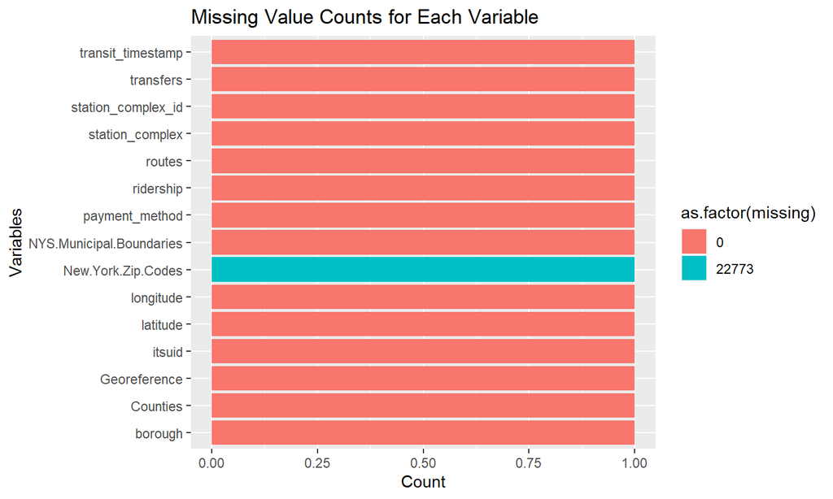

The following interprets the skewness values for each variable in the data-set, providing a clear understanding of the distribution of each variable. It’s a good way to identify whether the data is skewed and in which direction.

- For positively skewed variables, it indicates a distribution with a longer right tail.
- For negatively skewed variables, it suggests a distribution with a longer left tail.
- For approximately symmetric variables, it highlights that the mean and median are close to each other.

```
## Skewness values for variables:
```

|  | x |
| --- | --- |
| transit_timestamp | NA |
| station_complex_id | NA |
| station_complex | NA |
| borough | NA |
| routes | NA |
| payment_method | NA |
| ridership | 5.4793007 |
| transfers | 16.8303692 |
| latitude | -0.1918495 |
| longitude | 0.9599016 |
| Georeference | NA |
| itsuid | NA |
| New.York.Zip.Codes | 1.1340056 |
| Counties | -0.5869489 |
| NYS.Municipal.Boundaries | -0.5865792 |

```
##
## Interpretation:
```

```
## ridership is positively skewed (right-skewed) with a skewness value of 5.48 .
## transfers is positively skewed (right-skewed) with a skewness value of 16.83 .
## latitude is negatively skewed (left-skewed) with a skewness value of -0.19 .
## longitude is positively skewed (right-skewed) with a skewness value of 0.96 .
## New.York.Zip.Codes is positively skewed (right-skewed) with a skewness value of 1.13 .
## Counties is negatively skewed (left-skewed) with a skewness value of -0.59 .
## NYS.Municipal.Boundaries is negatively skewed (left-skewed) with a skewness value of -0.59 .
```

Skewness is a measure of the asymmetry of a probability distribution. Here’s how to interpret the provided skewness values:

1. **ridership**: The variable “ridership” is positively skewed (right-skewed) with a skewness value of 5.48. This indicates that the distribution has a long right tail, meaning there are some extreme values on the higher end.
2. **transfers**: The variable “transfers” is strongly positively skewed (right-skewed) with a skewness value of 16.83. This suggests a highly asymmetric distribution with a very long right tail, indicating the presence of extreme values on the higher end.
3. **latitude**: The variable “latitude” is negatively skewed (left-skewed) with a skewness value of -0.19. This implies that the distribution has a long left tail, meaning there are some extreme values on the lower end.
4. **longitude**: The variable “longitude” is positively skewed (right-skewed) with a skewness value of 0.96. Similar to “ridership,” this indicates a distribution with a long right tail and some extreme values on the higher end.
5. **New.York.Zip.Codes**: The variable “New.York.Zip.Codes” is positively skewed (right-skewed) with a skewness value of 1.13. This suggests a distribution with a longer right tail and potential extreme values on the higher end.
6. **Counties**: The variable “Counties” is negatively skewed (left-skewed) with a skewness value of -0.59. This implies a distribution with a long left tail, indicating the presence of some extreme values on the lower end.
7. **NYS.Municipal.Boundaries**: The variable “NYS.Municipal.Boundaries” is also negatively skewed (left-skewed) with a skewness value of -0.59. Similar to “Counties,” this suggests a distribution with a long left tail and potential extreme values on the lower end.

In summary, skewness values provide insights into the shape and symmetry of the distributions. Positive skewness indicates a tail on the right side, while negative skewness indicates a tail on the left side. The magnitude of skewness reflects the extent of asymmetry, with larger values indicating more pronounced skewness.

The preprocessing/cleaning of the transit ridership data includes; renaming and feature engineering tasks to prepare the dataframe for further analysis or visualization.

1. **Remove Unnecessary Columns:**
   - Drop columns ‘NYS Municipal Boundaries’ and ‘station_complex_id’ from the dataframe.
2. **Rename Columns:**
   - Rename columns to match specified names, including changing ‘transit_timestamp’ to ‘Transit_Date’ and other similar changes.
3. **Add a New Column ‘Borough_Name’:**
   - Based on the values in the ‘Borough_ID’ column, create a new column ‘Borough_Name’ mapping borough codes to borough names.
4. **Convert ‘Transit_Date’ to Datetime:**
   - Change the ‘Transit_Date’ column to a datetime object using the specified format.
5. **Add Columns for Weekday, Month, and Year:**
   - Create a new column ‘TransitDateName’ for the weekday.
   - Add columns ‘Transit_Month’ and ‘Transit_MonthN’ for the month name and month number, respectively.
   - Add a column ‘Transit_Year’ for the year.
6. **Add a New Column ‘Transit_Timestamp’:**
   - Create a new column ‘Transit_Timestamp’ by converting ‘Transit_Date’ to a datetime object with a specific format.
7. **Add Columns for Day, Hour, Time:**
   - Create columns ‘Ridership_Day’ for the day of the month, ‘Ridership_Hour’ for the hour of the day, ‘Transit_Time’ for the time in HH:MM:SS format.

The following displays histograms for the numeric variables **`Total_Ridership`** and **`Total_Transfers`** from the **`ridership_df`** data frame, presenting them in separate facets. It’s a visualization to understand the distribution of these numeric variables.

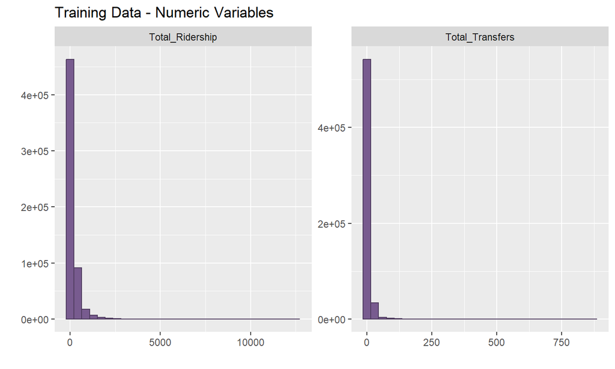

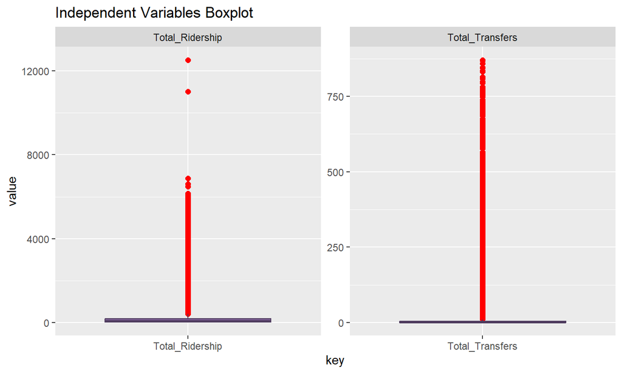

The variable plots below shows the plot of each **`TRANSFER`** versus the target variable, **`RIDERSHIP`**, to get an idea of the relationship between each.

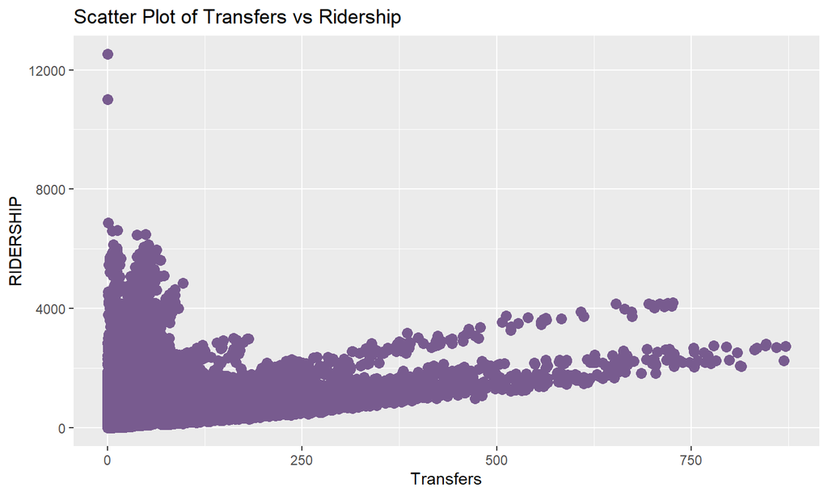

As shown below , the borough with the highest ridership is Manhattan followed by Brooklyn and Queens. Bronx displays the lowest ridership.

```
## # A tibble: 4 × 2
##   Borough_Name Total_Ridership
##   <fct>                  <int>
## 1 Queens              11957207
## 2 Manhattan           62695349
## 3 Bronx                6239999
## 4 Brooklyn            14257538
```

The following is a bar plot that shows the total subway ridership for each borough, with specific formatting and labeling for better interpretation.

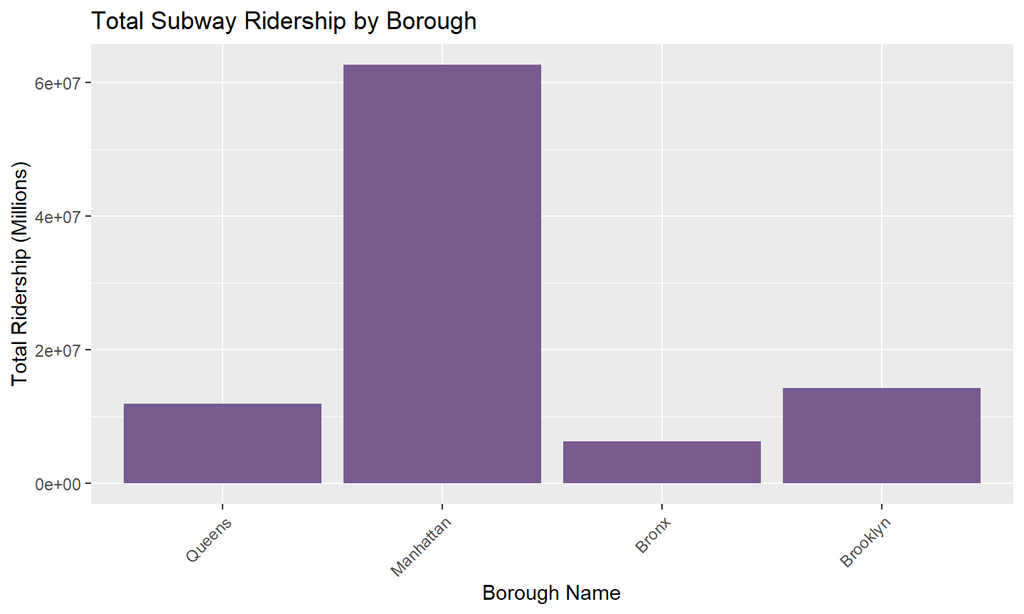

### DATA PREPARATION

### MODEL BUILDING

#### Multiple Linear Regression Model

Fits a multiple linear regression model (**`lm_model`**). The response variable is **`Total_Ridership`**, and the predictors include **`Borough_Name`** and **`payment_method`**.

```r
# Fit the Multiple Linear Regression
lm_model <- lm(Total_Ridership ~ Borough_Name + payment_method, data = train_data)

# Display a summary of the model
summary(lm_model)
```

```
##
## Call:
## lm(formula = Total_Ridership ~ Borough_Name + payment_method,
##     data = train_data)
##
## Residuals:
##     Min      1Q  Median      3Q     Max
##  -282.0   -94.8   -60.5    19.9 12451.4
##
## Coefficients:
##                       Estimate Std. Error t value Pr(>|t|)
## (Intercept)           100.7560     1.0535  95.638   <2e-16 ***
## Borough_NameManhattan 182.2208     1.1941 152.596   <2e-16 ***
## Borough_NameBronx     -18.2294     1.5344 -11.880   <2e-16 ***
## Borough_NameBrooklyn   -2.6524     1.2958  -2.047   0.0407 *
## payment_methodomny     -8.8998     0.8868 -10.036   <2e-16 ***
## ---
## Signif. codes:  0 '***' 0.001 '**' 0.01 '*' 0.05 '.' 0.1 ' ' 1
##
## Residual standard error: 303.2 on 467692 degrees of freedom
## Multiple R-squared:  0.08377,    Adjusted R-squared:  0.08376
## F-statistic: 1.069e+04 on 4 and 467692 DF,  p-value: < 2.2e-16
```

The following are diagnostic plots for the linear regression model (**`lm_model`**). Diagnostic plots are commonly used to assess the assumptions and performance of a regression model. The specific plots generated includes a scatterplot of residuals against fitted values, a Q-Q plot (quantile-quantile plot) for assessing normality of residuals, a scale-location plot for assessing homoscedasticity, and a residuals vs. leverage plot for identifying influential observations.

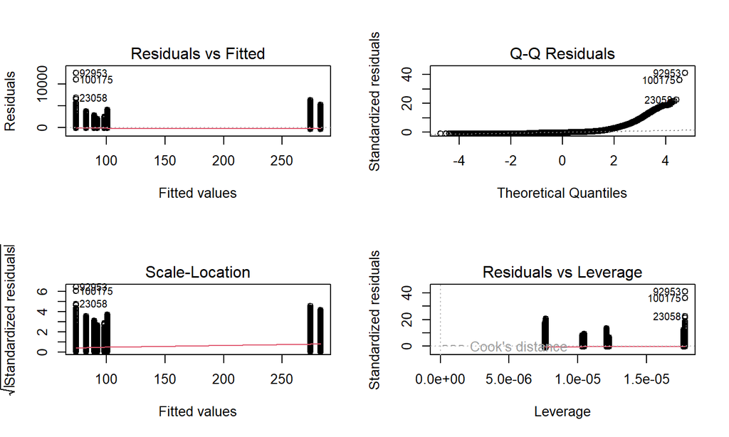

#### Simple Linear Regression Model

Fits a simple linear regression model using the **`lm`** function, predicting **`Total_Ridership`** based on the predictor variable **`Total_Transfers`** from the **`train_data`** dataset.

```r
# Fit the Simple Linear Regression
lm_simple <- lm(Total_Ridership ~ Total_Transfers, data = train_data)

# Display a summary of the model
summary(lm_simple)
```

```
##
## Call:
## lm(formula = Total_Ridership ~ Total_Transfers, data = train_data)
##
## Residuals:
##     Min      1Q  Median      3Q     Max
## -3235.8  -121.0   -87.0     9.5 12393.0
##
## Coefficients:
##                  Estimate Std. Error t value Pr(>|t|)
## (Intercept)     131.98425    0.43475   303.6   <2e-16 ***
## Total_Transfers   6.15977    0.01992   309.2   <2e-16 ***
## ---
## Signif. codes:  0 '***' 0.001 '**' 0.01 '*' 0.05 '.' 0.1 ' ' 1
##
## Residual standard error: 288.6 on 467695 degrees of freedom
## Multiple R-squared:  0.1697, Adjusted R-squared:  0.1697
## F-statistic: 9.56e+04 on 1 and 467695 DF,  p-value: < 2.2e-16
```

The following are diagnostic plots for the simple linear regression model (**`lm_simple`**) that was fitted earlier.

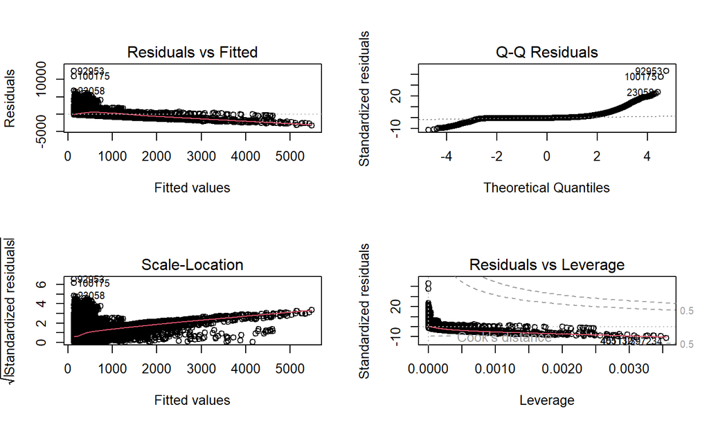

```r
# Set up a 2x2 plotting layout
par(mfrow = c(2, 2))

# Generate diagnostic plots for Model 2
plot(lm_simple)
```

#### Binary Logistic Regression Model

Fitting a binary logistic regression model to predict Metro Card payment based on the total ridership and total transfers, and then it displays a detailed summary of the model’s parameters and statistics. The **`glm`** function was used to predict the binary outcome variable **`Metro_Card_Payment`** based on the predictor variables **`Total_Ridership`** and **`Total_Transfers`**

```r
# Fit the Binary Logistic Regression
logistic_model <- glm(Metro_Card_Payment ~ Total_Ridership + Total_Transfers, data = train_data, family = "binomial")

# Display a summary of the model
summary(logistic_model)
```

```
##
## Call:
## glm(formula = Metro_Card_Payment ~ Total_Ridership + Total_Transfers,
##     family = "binomial", data = train_data)
##
## Coefficients:
##                   Estimate Std. Error z value Pr(>|z|)
## (Intercept)      1.535e-02  3.302e-03    4.65 3.32e-06 ***
## Total_Ridership  1.257e-04  1.027e-05   12.24  < 2e-16 ***
## Total_Transfers -1.698e-03  1.568e-04  -10.83  < 2e-16 ***
## ---
## Signif. codes:  0 '***' 0.001 '**' 0.01 '*' 0.05 '.' 0.1 ' ' 1
##
## (Dispersion parameter for binomial family taken to be 1)
##
##     Null deviance: 648280  on 467696  degrees of freedom
## Residual deviance: 648086  on 467694  degrees of freedom
## AIC: 648092
##
## Number of Fisher Scoring iterations: 3
```

The diagnostic plots displayed for the logistic regression model (**`logistic_model`**) are useful for assessing the assumptions and performance of the logistic regression model. Each of the four plots typically provides insights into different aspects of the model, such as residuals, linearity, and influential observations.

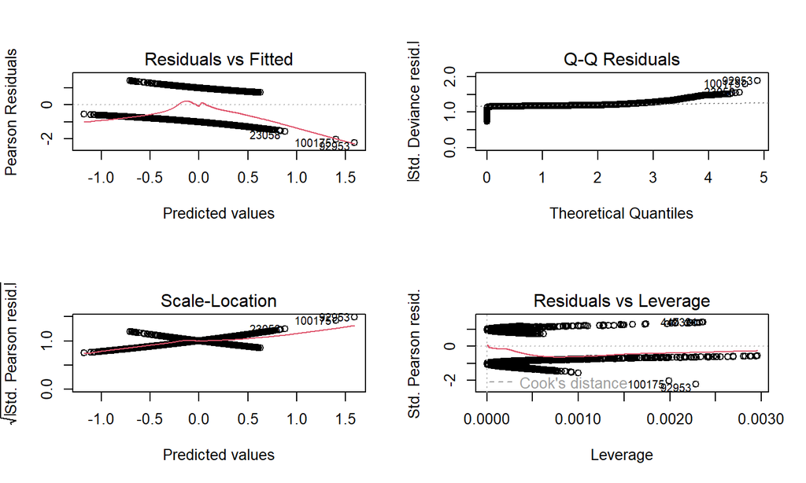

```r
# Set up a 2x2 plotting layout
par(mfrow = c(2, 2))

# Generate diagnostic plots for Model 3
plot(logistic_model)
```

#### Count Regression (Poisson Binomial) Model

Fits a count regression model (Poisson Binomial) using the **`glm`** function. It predicts the count variable **`Total_Transfers`** based on the predictors **`Borough_Name`** and **`payment_method`** from the **`train_data`** dataset.

```r
# Fit the Count Regression (Poisson or Negative Binomial)
poisson_model <- glm(Total_Transfers ~ Borough_Name + payment_method, data = train_data, family = "poisson")

# Display a summary of the model
summary(poisson_model)
```

```
##
## Call:
## glm(formula = Total_Transfers ~ Borough_Name + payment_method,
##     family = "poisson", data = train_data)
##
## Coefficients:
##                        Estimate Std. Error z value Pr(>|z|)
## (Intercept)            1.464655   0.001629  898.88   <2e-16 ***
## Borough_NameManhattan  0.457320   0.001734  263.73   <2e-16 ***
## Borough_NameBronx     -0.208910   0.002552  -81.87   <2e-16 ***
## Borough_NameBrooklyn  -0.141150   0.002085  -67.70   <2e-16 ***
## payment_methodomny     0.073916   0.001279   57.81   <2e-16 ***
## ---
## Signif. codes:  0 '***' 0.001 '**' 0.01 '*' 0.05 '.' 0.1 ' ' 1
##
## (Dispersion parameter for poisson family taken to be 1)
##
##     Null deviance: 8092563  on 467696  degrees of freedom
## Residual deviance: 7889404  on 467692  degrees of freedom
## AIC: 8741914
##
## Number of Fisher Scoring iterations: 7
```

The diagnostic plots for the count regression model (**`poisson_model`**) displayed below are valuable for assessing the assumptions and performance of the count regression model.

The **`plot(poisson_model)`** function generates diagnostic plots that commonly include:

1. **Residuals vs. Fitted Values:** Assessing the relationship between the observed and predicted values.
2. **Q-Q Plot:** Evaluating the assumption of normality for the residuals.
3. **Scale-Location Plot:** Examining the homogeneity of variance (homoscedasticity) of the residuals.
4. **Residuals vs. Leverage Plot:** Identifying influential observations.

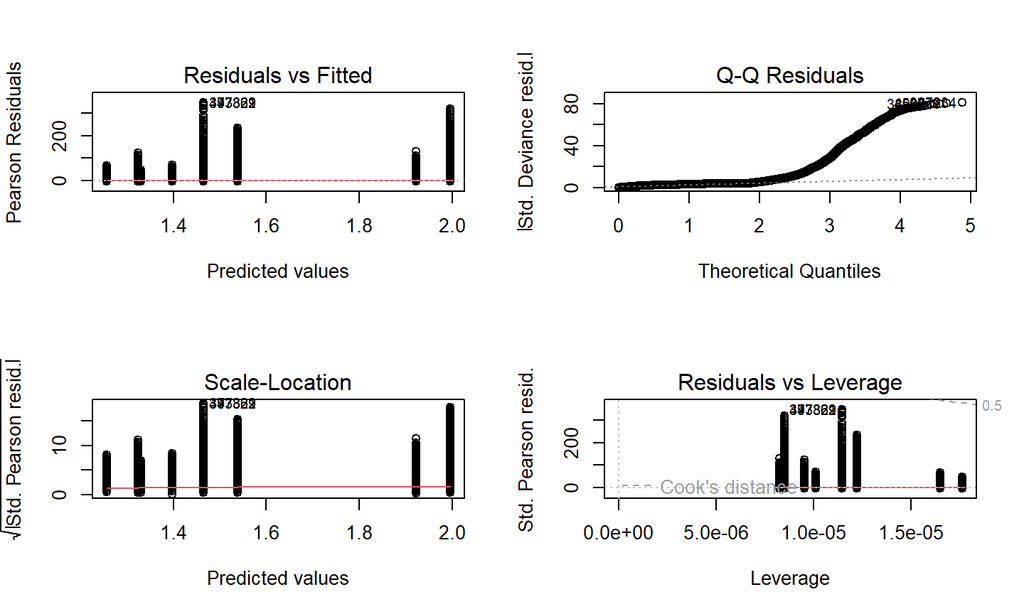

```r
# Set up a 2x2 plotting layout
par(mfrow = c(2, 2))

# Generate diagnostic plots for Model 2
plot(poisson_model)
```

#### Negative Binomial Regression Model

The negative binomial regression model displayed below was fitted using the **`glm.nb`** function. It predicts the count variable **`Total_Ridership`** based on the predictor variable **`Borough_Name`** from the **`train_data`** dataset.

```r
# Fit the negative binomial regression model
Model_NegBinom <- glm.nb(Total_Ridership ~ Borough_Name, data = train_data)

# Display a summary of the model
summary(Model_NegBinom)
```

```
##
## Call:
## glm.nb(formula = Total_Ridership ~ Borough_Name, data = train_data,
##     init.theta = 0.6122448352, link = log)
##
## Coefficients:
##                        Estimate Std. Error  z value Pr(>|z|)
## (Intercept)            4.568549   0.004060 1125.300  < 2e-16 ***
## Borough_NameManhattan  1.061068   0.005046  210.297  < 2e-16 ***
## Borough_NameBronx     -0.209997   0.006491  -32.352  < 2e-16 ***
## Borough_NameBrooklyn  -0.028160   0.005479   -5.139 2.76e-07 ***
## ---
## Signif. codes:  0 '***' 0.001 '**' 0.01 '*' 0.05 '.' 0.1 ' ' 1
##
## (Dispersion parameter for Negative Binomial(0.6122) family taken to be 1)
##
##     Null deviance: 655832  on 467696  degrees of freedom
## Residual deviance: 567365  on 467693  degrees of freedom
## AIC: 5478913
##
## Number of Fisher Scoring iterations: 1
##
##
##               Theta:  0.61224
##           Std. Err.:  0.00109
##
##  2 x log-likelihood:  -5478902.83400
```

Diagnostic plots for the negative binomial regression model (**`Model_NegBinom`**)

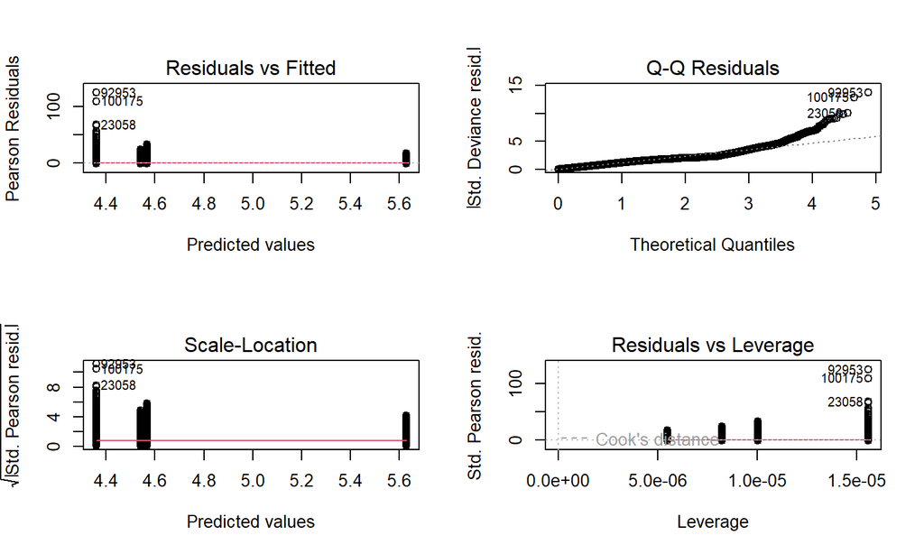

```r
# Set up a 2x2 plotting layout
par(mfrow = c(2, 2))

# Generate diagnostic plots for Model 5
plot(Model_NegBinom)
```

#### Generalized Linear Models (GLM) Model

The generalized linear model (GLM) was fitted with a Poisson family using the **`glm`** function. It predicts the count variable **`Total_Ridership`** based on the predictor variables **`Borough_Name`** and **`payment_method`** from the **`train_data`** dataset.

The summary includes various statistics such as coefficients, standard errors, z-values, and p-values for the predictors. It also provides information on the overall fit of the model, including the deviance and AIC (Akaike Information Criterion).

```r
# Fit the Generalized Linear Models (GLM)
glm_model <- glm(Total_Ridership ~ Borough_Name + payment_method, data = train_data, family = "poisson")

# Display a summary of the model
summary(glm_model)
```

```
##
## Call:
## glm(formula = Total_Ridership ~ Borough_Name + payment_method,
##     family = "poisson", data = train_data)
##
## Coefficients:
##                         Estimate Std. Error  z value Pr(>|z|)
## (Intercept)            4.5946914  0.0003403 13501.86   <2e-16 ***
## Borough_NameManhattan  1.0614914  0.0003517  3018.05   <2e-16 ***
## Borough_NameBronx     -0.2098093  0.0005508  -380.89   <2e-16 ***
## Borough_NameBrooklyn  -0.0280109  0.0004381   -63.94   <2e-16 ***
## payment_methodomny    -0.0542141  0.0002284  -237.40   <2e-16 ***
## ---
## Signif. codes:  0 '***' 0.001 '**' 0.01 '*' 0.05 '.' 0.1 ' ' 1
##
## (Dispersion parameter for poisson family taken to be 1)
##
##     Null deviance: 142385624  on 467696  degrees of freedom
## Residual deviance: 119107711  on 467692  degrees of freedom
## AIC: 121813878
##
## Number of Fisher Scoring iterations: 6
```

Diagnostic plots for the generalized linear model (GLM) with a Poisson family (**`glm_model`**).

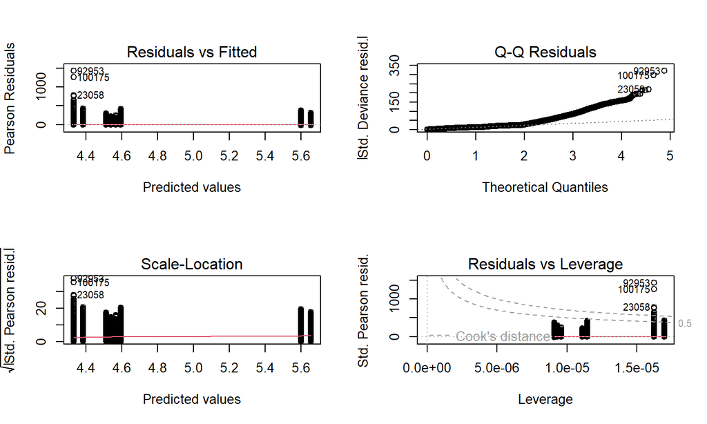

```r
# Set up a 2x2 plotting layout
par(mfrow = c(2, 2))

# Generate diagnostic plots for Model 5
plot(glm_model)
```

### SELECT MODEL

The following section compares the six different models (Model 1 to Model 6) and summarizes their performance metrics. The data is outputted in a table that provides a comprehensive overview of the performance of each model, making it easy to compare their AIC, MSE, AUC, accuracy, and class error rate. This information can be valuable for selecting the best-performing model for the given dataset and task.

**Model Evaluation Metrics**

**Model Evaluation Summary**

It’s important to consider the context of the analysis being performed, the nature of the data being analyzed, and the goals of the modeling when selecting the most appropriate model.

- **Model 2** stands out with a perfect AUC of 1.0, indicating excellent discrimination between classes. However, it has a low accuracy, suggesting imbalanced classes.
- **Model 3** has the lowest AIC and MSE, suggesting good model fit and predictive performance.
- **Model 4** has a relatively low accuracy and high class error rate, indicating challenges in classification.

```r
# comparing all models
CM1 <- confusionMatrix(factor(ifelse(predict(lm_model, train_data, type = "response") >= 1, 1, 0)), factor(train_data$Total_Ridership), positive = "1")
CM2 <- confusionMatrix(factor(ifelse(predict(lm_simple, train_data, type = "response") >= 1, 1, 0)), factor(train_data$Total_Ridership), positive = "1")
#CM2 <- confusionMatrix(as.factor(as.integer(fitted(lm_simple) > .5)), as.factor(lm_simple$y), positive = "1")
CM3 <- confusionMatrix(as.factor(as.integer(fitted(logistic_model) > .5)), as.factor(logistic_model$y), positive = "1")
CM4 <- confusionMatrix(as.factor(as.integer(fitted(poisson_model) > .5)), as.factor(poisson_model$y), positive = "1")
CM5 <- confusionMatrix(as.factor(as.integer(fitted(Model_NegBinom) > .5)), as.factor(Model_NegBinom$y), positive = "1")
CM6 <- confusionMatrix(as.factor(as.integer(fitted(glm_model) > .5)), as.factor(glm_model$y), positive = "1")
# Calculate AIC, MSE, and AUC for each model
aic1 <- AIC(lm_model)
aic2 <- AIC(lm_simple)
aic3 <- AIC(logistic_model)
aic4 <- AIC(poisson_model)
aic5 <- AIC(Model_NegBinom)
aic6 <- AIC(glm_model)

mse1 <- mean((train_data$Total_Transfers - predict(lm_model))^2)
mse2 <- mean((train_data$Total_Transfers - predict(lm_simple))^2)
mse3 <- mean((train_data$Metro_Card_Payment - predict(logistic_model))^2)
mse4 <- mean((train_data$Total_Transfers - predict(poisson_model))^2)
mse5 <- mean((train_data$Total_Ridership - predict(Model_NegBinom))^2)
mse6 <- mean((train_data$Total_Ridership - predict(glm_model))^2)

# Calculate AUC for each model
auc1 <- roc(train_data$Total_Transfers, predict(lm_model))
auc2 <- roc(train_data$Total_Transfers, predict(lm_simple))
auc3 <- roc(train_data$Metro_Card_Payment, predict(logistic_model))
auc4 <- roc(train_data$Total_Transfers, predict(poisson_model))
auc5 <- roc(train_data$Total_Ridership, predict(Model_NegBinom))
auc6 <- roc(train_data$Total_Ridership, predict(glm_model))
# Calculate the Accuracy for each model
Accuracy1 <- c(CM1$overall[1])
Accuracy2 <- c(CM2$overall[1])
Accuracy3 <- c(CM3$overall[1])
Accuracy4 <- c(CM4$overall[1])
Accuracy5 <- c(CM5$overall[1])
Accuracy6 <- c(CM5$overall[1])

# Calculate the Class. Error Rate for each model
cle1 <- c("Class. Error Rate" = 1 - as.numeric(CM1$overall[1]))
cle2 <- c("Class. Error Rate" = 1 - as.numeric(CM2$overall[1]))
cle3 <- c("Class. Error Rate" = 1 - as.numeric(CM3$overall[1]))
cle4 <- c("Class. Error Rate" = 1 - as.numeric(CM4$overall[1]))
cle5 <- c("Class. Error Rate" = 1 - as.numeric(CM5$overall[1]))
cle6 <- c("Class. Error Rate" = 1 - as.numeric(CM6$overall[1]))


# Create a data frame with AIC, MSE, and AUC values
model_comparison <- data.frame(
  Model = c("Model 1", "Model 2", "Model 3", "Model 4", "Model 5", "Model 6"),
  AIC = c(aic1, aic2, aic3, aic4, aic5, aic6),
  MSE = c(mse1, mse2, mse3, mse4, mse5, mse6),
  AUC = c(auc1$auc, auc2$auc, auc3$auc, auc4$auc, auc5$auc, auc6$auc),
  Accuracy = c(Accuracy1, Accuracy2, Accuracy3, Accuracy4, Accuracy5, Accuracy6),
  'Class Error Rate' = c(cle1, cle2, cle3, cle4, cle5, cle6)
)

# Display the model comparison table
kable(model_comparison) %>%
  kable_styling(full_width = T)
```

| Model | AIC | MSE | AUC | Accuracy | Class.Error.Rate |
| --- | --- | --- | --- | --- | --- |
| Model 1 | 6672490.4 | 3.386197e+04 | 0.5098811 | 0.0288178 | 0.9711822 |
| Model 2 | 6626418.4 | 3.722860e+04 | 1.0000000 | 0.0288178 | 0.9711822 |
| Model 3 | 648091.6 | 4.808948e-01 | 0.5573146 | 0.5075123 | 0.4924877 |
| Model 4 | 8741913.7 | 4.611086e+02 | 0.5066124 | 0.1336399 | 0.8663601 |
| Model 5 | 5478912.8 | 1.256081e+05 | 0.5102898 | 0.0288178 | 0.9711822 |
| Model 6 | 121813877.9 | 1.256080e+05 | 0.5259317 | 0.0288178 | 0.9711822 |

### MODEL PREDICTION

**Making predictions on logistic_model**

The predictions include two columns: **`Metro_Card_Payment`** and **`Predicted_Probability`**.

- **`Metro_Card_Payment`** is a logical (boolean) column indicating whether the actual payment method is a Metro Card. In this context, **`TRUE`** could mean that the payment method is a Metro Card, and **`FALSE`** could mean it’s not.
- **`Predicted_Probability`** is a numeric column representing the predicted probability of the payment method being a Metro Card, based on the logistic regression model.

In summary, each row provides the model’s prediction for whether the payment method is a Metro Card (**`TRUE`** or **`FALSE`**) along with the associated predicted probability. These probabilities can be interpreted as the model’s confidence in its predictions, with higher probabilities indicating higher confidence.

```r
# Making predictions on logistic_model using the Test Data
logistic_predictions <- predict(logistic_model, newdata = test_data, type = "response")

# Assign the predictions to a new column in the test_data dataframe
test_data$Predicted_Probability <- logistic_predictions

# Display the first few rows of the updated test_data dataframe with predictions
head(test_data[, c("Metro_Card_Payment", "Predicted_Probability")])
```

```
## # A tibble: 6 × 2
## # Rowwise:
##   Metro_Card_Payment Predicted_Probability
##   <lgl>                              <dbl>
## 1 FALSE                              0.504
## 2 FALSE                              0.504
## 3 FALSE                              0.504
## 4 TRUE                               0.504
## 5 FALSE                              0.504
## 6 TRUE                               0.505
```

**Making predictions on lm_simple model**

The predictions include two columns: **`Total_Ridership`** and **`Predicted_Total_Ridership`**.

- **`Total_Ridership`** is an integer column representing the actual or observed total ridership.
- **`Predicted_Total_Ridership`** is a numeric column representing the predicted total ridership based on the model.

Interpretation of each row:

1. The first row predicts a total ridership of 132, while the actual observed total ridership (**`Total_Ridership`**) is 7.
2. The second row predicts a total ridership of 132, while the actual observed total ridership (**`Total_Ridership`**) is 15.
3. The third row predicts a total ridership of 132, while the actual observed total ridership (**`Total_Ridership`**) is 10.
4. The fourth row predicts a total ridership of 132, while the actual observed total ridership (**`Total_Ridership`**) is 2.
5. The fifth row predicts a total ridership of 132, while the actual observed total ridership (**`Total_Ridership`**) is 9.
6. The sixth row predicts a total ridership of 132, while the actual observed total ridership (**`Total_Ridership`**) is 28.

Each row in the prediction provides the model’s prediction for the total ridership (**`Predicted_Total_Ridership`**) alongside the actual observed total ridership (**`Total_Ridership`**). The predicted values represent the model’s estimate of what the total ridership might be based on the features included in the model.

```
## # A tibble: 6 × 2
## # Rowwise:
##   Total_Ridership Predicted_Total_Ridership
##             <int>                     <dbl>
## 1               7                       132
## 2              15                       132
## 3              10                       132
## 4               2                       132
## 5               9                       132
## 6              28                       132
```

### MODEL SELECTION

**Criteria for Selecting the Best Model**

The criteria for selecting the best model can vary based on the specific goals of the analysis and the characteristics of the data. Here are some common criteria used for selecting the best model:

1. **Goodness of Fit:**
   - Evaluate how well the model fits the observed data. This can be assessed using metrics like mean squared error (MSE), root mean squared error (RMSE), or R-squared.
2. **Model Interpretability:**
   - Consider the interpretability of the model. Simpler models that are easier to interpret are often preferred, especially in scenarios where understanding the relationship between variables is crucial.
3. **Cross-Validation Performance:**
   - Assess the performance of the model on unseen data using cross-validation techniques. This helps to ensure that the model generalizes well to new, unseen observations.
4. **AIC and BIC:**
   - Use information criteria such as Akaike Information Criterion (AIC) or Bayesian Information Criterion (BIC) to balance goodness of fit and model complexity. Lower values indicate a better trade-off.
5. **Residual Analysis:**
   - Examine the residuals (the differences between predicted and observed values) to ensure that the model assumptions are met. Residual plots and diagnostic statistics can be helpful in identifying issues.
6. **Variable Importance:**
   - If applicable, consider the importance of predictor variables. Some models provide information on variable importance, helping to identify which features contribute most to the model’s predictions.
7. **Predictive Performance:**
   - Evaluate the model’s predictive performance on a test dataset. Metrics like accuracy, precision, recall, or area under the ROC curve (AUC-ROC) can be used, depending on the nature of the problem (classification, regression).
8. **Computational Efficiency:**
   - Consider the computational efficiency of the model, especially for large datasets. Some models may be computationally expensive and not practical for certain applications.
9. **Robustness:**
   - Assess how well the model performs under different conditions and whether it is robust to changes in the dataset or assumptions.
10. **Domain Knowledge:**
    - Incorporate domain knowledge and business context into the evaluation. A model that aligns with domain expertise is often more valuable.

It’s important to note that the choice of criteria depends on the specific context, and it may involve a trade-off between different factors. The ultimate goal is to select a model that best meets the objectives of the analysis and performs well in practical applications.

## **Discussion and Conclusions**

### **Limitations:**

- The findings are contingent on the assumptions and limitations of the models used. It’s crucial to be aware of these limitations when interpreting the results.
- The quality of predictions relies on the quality of the data. Inaccurate or incomplete data may impact the reliability of the models.
- The chosen models may not capture all nuances of the underlying data, and there might be unaccounted factors influencing the outcomes.
- Overfitting or underfitting might occur, affecting the generalizability of the models to new data.

### **Suggestions for Future Work:**

- **Feature Engineering:** Explore additional features or transformations that might enhance model performance.
- **Data Quality:** Address data quality issues and outliers that could impact model accuracy.
- **Temporal Patterns:** Investigate temporal patterns or seasonality effects that could influence ridership.
- **Ensemble Models:** Consider using ensemble models to combine predictions from multiple models for improved robustness.
- **Advanced Techniques:** Explore advanced techniques like deep learning or time-series analysis for more sophisticated modeling.
- **External Factors:** Include external factors such as weather conditions, holidays, or special events that might impact ridership.
- **User Feedback:** If applicable, gather feedback from end-users or stakeholders to refine models based on practical insights.

### **Conclusion:**

- The analysis provides valuable insights into MTA ridership, but it’s important to acknowledge the limitations.
- Model selection should align with the specific goals of the analysis and the characteristics of the data.
- Continuous refinement and validation of models are essential for maintaining their relevance and accuracy over time.

## **References**

1. The “MTA Subway Hourly Ridership” Data used in the analysis and can found here: https://data.ny.gov/Transportation/MTA-Subway-Hourly-Ridership-Beginning-February-202/wujg-7c2s
2. Sage Journals “Examination of New York City Transit’s Bus and Subway Ridership Trends During the COVID-19 Pandemic”: https://journals.sagepub.com/doi/10.1177/03611981211028860

## **Appendices**

```r
if(FALSE) {



pkges <- c("tidyverse", "kableExtra", "readr", "dplyr", "ggplot2", "mice", "VIM", "fBasics", "reshape2", "tidyr", "gdata", "corrgram", "moments", "summarytools", "corrplot", "knitr", "viridis", "psych", "visdat", "DMwR2", "MASS", "zoo", "Metrics", "caret", "e1071", "car", "MASS", "geoR", "pROC", "gridExtra", "Hmisc", "PerformanceAnalytics", "RANN", "caTools", "nnet", "plm")

# Loop through the packages
for (p in pkges) {
  # Check if package is installed
  if (!requireNamespace(p, quietly = TRUE)) {
    install.packages(p) #If the package is not installed, install the package

    library(p, character.only = TRUE) #Load the package
  } else {
    library(p, character.only = TRUE) #If the package is already installed, load the package
  }
}


# URL of the zip file
zip_url <- "https://raw.githubusercontent.com/BeshkiaKvarnstrom/DATA-602-Advanced-Programming-Techniques/main/Data/MTA_Subway_Hourly_Ridership__Beginning_August-September-2023.zip"

# Download the zip file
response <- httr::GET(url = zip_url, httr::write_disk("ridership.zip", overwrite = TRUE))

# Check if the request was successful
if (httr::status_code(response) == 200) {
  # Unzip the file
  unzip("ridership.zip", exdir = "ridership_data")

  # Get the name of the CSV file
  ridership_csv <- list.files("ridership_data", pattern = "\\.csv$", full.names = TRUE)[1]

  # Read the CSV file into a data frame
  ridership_df <- read.csv(ridership_csv)
} else {
  cat("Failed to download the zip file. Status code:", httr::status_code(response), "\n")
}


# Display the top 10 rows in the data
ridership_df %>%
  slice_head(n = 10) %>%
  kable() %>%
  kable_styling(bootstrap_options = "striped", font_size = 12) %>%
  scroll_box(height = "300px", width = "100%")

# Print the number of observations in the dataset
print(paste0('There are ',nrow(ridership_df),' observations/cases in the dataset'))

# Number of exploratory variables
num_exploratory_variables <- ncol(ridership_df)

# Number of explanatory variables
num_explanatory_variables <- ncol(ridership_df) - 2  # Subtract 2 for the index target variable

# Print information about the dataset
print(paste0('There are ',num_exploratory_variables,' columns/elements in the Insurance dataset'))
print(paste0('There are ',num_explanatory_variables,' explanatory variables in the Training dataset'))


# Use sapply to apply the class function to each column, obtaining column types
column_types <- sapply(ridership_df, class)

# Use table to get the frequency of each column type
type_frequency <- table(column_types)

# Print the type frequency table
print(type_frequency)



Ridership_Sum <- data.frame(
  Variable = character(),
  Min = integer(),
  Median = integer(),
  Mean = double(),
  SD = double(),
  Q1 = double(),
  Q3 = double(),
  Max = integer(),
  Num_NAs = integer(),
  Num_Zeros = integer()
)

for (i in seq_along(ridership_df)) {
  column_name <- names(ridership_df)[i]
  column_data <- ridership_df[[i]]

  # Skip non-numeric columns
  if (!is.numeric(column_data)) {
    cat("Skipping non-numeric column:", column_name, "\n")
    next
  }

  Ridership_Sum <- rbind(Ridership_Sum, data.frame(
    Variable = column_name,
    Min = min(column_data, na.rm = TRUE),
    Median = median(column_data, na.rm = TRUE),
    Mean = mean(column_data, na.rm = TRUE),
    SD = sd(column_data, na.rm = TRUE),
    Q1 = quantile(column_data, 0.25, na.rm = TRUE),
    Q3 = quantile(column_data, 0.75, na.rm = TRUE),
    Max = max(column_data, na.rm = TRUE),
    Num_NAs = sum(is.na(column_data)),
    Num_Zeros = length(which(column_data == 0))
  ))
}

colnames(Ridership_Sum) <- c("", "Min", "Median", "Mean", "SD", "Q1", "Q3",  "Max", "Num of NAs",
                             "Num of Zeros")
Ridership_Sum %>% kable() %>%
  kable_styling(bootstrap_options = "striped", font_size = 12) %>%
  scroll_box(height = "300px", width = "100%")




# Set the option to disable the warning about large data
options(visdat.warn_large_data = FALSE)

# Identify the variables with missing values
ridership_df %>%
  gather(variable, value) %>%
  filter(is.na(value)) %>%
  group_by(variable) %>%
  tally() %>%
  mutate(percent = n / nrow(ridership_df) * 100) %>%
  mutate(percent = ifelse(length(percent) > 0, paste0(round(percent, 1), "%"), "0%")) %>%
  arrange(desc(n)) %>%
  kable() %>%
  kable_styling(bootstrap_options = "striped", font_size = 12, full_width = F, position = "left") %>%
  scroll_box(height = "100%", width = "100%", fixed_thead = T)

# Visualize NA counts for each column
ridership_df %>%
  summarise_all(list(~sum(is.na(.)))) %>%
  pivot_longer(everything(),
               names_to = "variables", values_to = "missing") %>%
  count(variables, missing) %>%
  ggplot(aes(x = n, y = variables, fill = as.factor(missing))) +
  geom_col() +
  labs(title = "Missing Value Counts for Each Variable",
       x = "Count",
       y = "Variables")



# Check skewness for all variables
skewness_values <- sapply(ridership_df, function(x) {
  if (is.numeric(x)) {
    skewness(x)
  } else {
    NA
  }
})

# Print skewness values for each variable
cat("Skewness values for variables:\n")
skewness_values%>% kable() %>%
  kable_styling(bootstrap_options = "striped", font_size = 12) %>%
  scroll_box(height = "300px", width = "100%")

# Interpret the skewness values
cat("\nInterpretation:\n")
cat("----------------------------\n")
for (var in names(ridership_df)) {
  if (!is.na(skewness_values[var])) {
    if (skewness_values[var] > 0) {
      cat(paste(var, "is positively skewed (right-skewed) with a skewness value of", round(skewness_values[var], 2), ".\n"))
    } else if (skewness_values[var] < 0) {
      cat(paste(var, "is negatively skewed (left-skewed) with a skewness value of", round(skewness_values[var], 2), ".\n"))
    } else {
      cat(paste(var, "is approximately symmetric with a skewness value of", round(skewness_values[var], 2), ".\n"))
    }
  }
}



###
fix_missing <- function(unclean_data) {
  unclean_data %>%
    rowwise() %>%
    mutate(across(c("Zip_Code"),
                  ~ ifelse(is.na(.), mean(., na.rm = TRUE), .)))
}
```

```r
# This function uses the filter function to exclude rows columns have a NaN (missing) value
remove_NA_values <- function(unclean_data) {
  unclean_data %>%
    filter(!is.na(Zip_Code) )
}
###


# Rename columns
ridership_df <- ridership_df %>%
  rename(Total_Ridership = ridership, Total_Transfers = transfers, Transit_Date = transit_timestamp, Subway_Station = station_complex, Borough_ID = borough, Zip_Code = 'New.York.Zip.Codes')


# Apply the processing steps above to the testing dataset
ridership_df <- ridership_df %>%
  fix_missing() %>%
  remove_NA_values()

# Remove unnecessary columns
ridership_df <- ridership_df[, !(names(ridership_df) %in% c('NYS Municipal Boundaries', 'station_complex_id'))]

# Remove content within parentheses from 'Subway_Station' and create 'station_name' column
ridership_df$station_name <- gsub("\\(.*\\)", "", ridership_df$Subway_Station)


# Add a new column 'Borough_Name'
ridership_df$Borough_Name <- factor(ridership_df$Borough_ID, levels = c('Q', 'M', 'BX', 'BK', 'SI'),
                                   labels = c('Queens', 'Manhattan', 'Bronx', 'Brooklyn', 'Staten Island'))

# Change Transit_Date to datetime object
ridership_df$Transit_Date <- as.Date(ridership_df$Transit_Date)

# Add a new column for the weekday
ridership_df$TransitDateName <- weekdays(ridership_df$Transit_Date)

# Add new columns for Transit Month
ridership_df$Transit_Month <- months(ridership_df$Transit_Date)
ridership_df$Transit_MonthN <- as.integer(format(ridership_df$Transit_Date, "%m"))

# Add a new column for Transit Timestamp
ridership_df$Transit_Timestamp <- format(ridership_df$Transit_Date, "%H:%M:%S")

# Add new columns for Transit Day, Transit Hour, Time, Year
ridership_df$Ridership_Day <- as.numeric(format(ridership_df$Transit_Date, format='%d'))
ridership_df$Ridership_Hour <- as.numeric(format(ridership_df$Transit_Date, format='%H'))
ridership_df$Transit_Time <- format(ridership_df$Transit_Date, format='%H:%M:%S')
ridership_df$Transit_Year <- as.numeric(format(ridership_df$Transit_Date, format='%Y'))



# Select numeric columns only
numeric_columns <- ridership_df %>%
  select_if(is.numeric)

# Gather and plot histograms for numeric variables
numeric_columns %>%
  gather(key, value, c(Total_Ridership, Total_Transfers)) %>%
  ggplot(aes(x = value)) +
  geom_histogram(fill = "#785B8F", color = "#4F3C5F", bins = 30) +  # Adjust the number of bins as needed
  facet_wrap(~key, scales = 'free') +
  labs(title = "Training Data - Numeric Variables", x = "", y = "", color = '#4F3C5F')



numeric_columns <- ridership_df %>%
  select_if(is.numeric)

if (any(numeric_cols)) {
  ridership_df %>%
    gather(key, value, na.rm = TRUE, c(Total_Ridership, Total_Transfers)) %>%
    ggplot(aes(x = key, y = value)) +
    geom_boxplot(fill = "#785B8F", color = "#4F3C5F", outlier.colour = "red", outlier.shape = 16,
                 outlier.size = 2, notch = FALSE)+
  labs(title = "Independent Variables Boxplot") +
    facet_wrap(~key, scales = "free", ncol = 4)
} else {
  print("No numeric columns found.")
}



ggplot(ridership_df, aes(x = Total_Transfers, y = Total_Ridership)) +
  geom_point(color = "#785B8F", size = 3) +
  labs(title = "Scatter Plot of Transfers vs Ridership",
       x = "Transfers",
       y = "RIDERSHIP",
       color = '#4F3C5F')



# Remove non-numeric or invalid values in Total_Ridership
ridership_df_cleaned <- ridership_df %>%
  filter(is.numeric(Total_Ridership))

# Group by 'Borough_Name' and calculate the total ridership for each borough
total_ridership_by_borough <- ridership_df_cleaned %>%
  group_by(Borough_Name) %>%
  summarise(Total_Ridership = sum(Total_Ridership, na.rm = TRUE))

# Print the result
print(total_ridership_by_borough)



# Plot the total ridership by borough
ggplot(total_ridership_by_borough, aes(x = Borough_Name, y = Total_Ridership)) +
  geom_bar(stat = "identity", fill = "#785B8F") +
  labs(title = 'Total Subway Ridership by Borough',
       x = 'Borough Name',
       y = 'Total Ridership (Millions)') +
  theme(axis.text.x = element_text(angle = 45, hjust = 1))



# Duplicate the dataset. The models will be built using the duplicated datasets.
Ridership_Dup <- ridership_df[, !(colnames(ridership_df) %in% c("itsuid", "latitude", "longitude", "Georeference", "NYS.Municipal.Boundaries"))]


#creates a new column named Metro_Card_Payment and sets its values to TRUE where the payment_method is "metrocard" and FALSE otherwise.
Ridership_Dup$Metro_Card_Payment <- Ridership_Dup$payment_method == "metrocard"
Ridership_Dup$Metro_Card_Payment <- as.logical(Ridership_Dup$Metro_Card_Payment)


# Splitting the Data
set.seed(812)  # Set seed for reproducibility
split_ratio <- 0.8  # 80% for training, 20% for testing

split <- sample.split(Ridership_Dup$Total_Ridership, SplitRatio = split_ratio)
train_data <- subset(Ridership_Dup, split == TRUE)
test_data <- subset(Ridership_Dup, split == FALSE)



# Fit the Multiple Linear Regression
lm_model <- lm(Total_Ridership ~ Borough_Name + payment_method, data = train_data)

# Display a summary of the model
summary(lm_model)



# Set up a 2x2 plotting layout
par(mfrow = c(2, 2))

# Generate diagnostic plots for Model 1
plot(lm_model)



# Fit the Simple Linear Regression
lm_simple <- lm(Total_Ridership ~ Total_Transfers, data = train_data)

# Display a summary of the model
summary(lm_simple)



# Set up a 2x2 plotting layout
par(mfrow = c(2, 2))

# Generate diagnostic plots for Model 2
plot(lm_simple)



# Fit the Binary Logistic Regression
logistic_model <- glm(Metro_Card_Payment ~ Total_Ridership + Total_Transfers, data = train_data, family = "binomial")

# Display a summary of the model
summary(logistic_model)



# Set up a 2x2 plotting layout
par(mfrow = c(2, 2))

# Generate diagnostic plots for Model 3
plot(logistic_model)



# Set up a 2x2 plotting layout
par(mfrow = c(2, 2))

# Generate diagnostic plots for Model 3
plot(logistic_model)


# Set up a 2x2 plotting layout
par(mfrow = c(2, 2))

# Generate diagnostic plots for Model 2
plot(poisson_model)
```

```r
# Fit the negative binomial regression model
Model_NegBinom <- glm.nb(Total_Ridership ~ Borough_Name, data = train_data)

# Display a summary of the model
summary(Model_NegBinom)


# Set up a 2x2 plotting layout
par(mfrow = c(2, 2))

# Generate diagnostic plots for Model 5
plot(Model_NegBinom)


# Fit the Generalized Linear Models (GLM)
glm_model <- glm(Total_Ridership ~ Borough_Name + payment_method, data = train_data, family = "poisson")

# Display a summary of the model
summary(glm_model)


# Set up a 2x2 plotting layout
par(mfrow = c(2, 2))

# Generate diagnostic plots for Model 5
plot(glm_model)


# comparing all models
CM1 <- confusionMatrix(factor(ifelse(predict(lm_model, train_data, type = "response") >= 1, 1, 0)), factor(train_data$Total_Ridership), positive = "1")
CM2 <- confusionMatrix(factor(ifelse(predict(lm_simple, train_data, type = "response") >= 1, 1, 0)), factor(train_data$Total_Ridership), positive = "1")
#CM2 <- confusionMatrix(as.factor(as.integer(fitted(lm_simple) > .5)), as.factor(lm_simple$y), positive = "1")
CM3 <- confusionMatrix(as.factor(as.integer(fitted(logistic_model) > .5)), as.factor(logistic_model$y), positive = "1")
CM4 <- confusionMatrix(as.factor(as.integer(fitted(poisson_model) > .5)), as.factor(poisson_model$y), positive = "1")
CM5 <- confusionMatrix(as.factor(as.integer(fitted(Model_NegBinom) > .5)), as.factor(Model_NegBinom$y), positive = "1")
CM6 <- confusionMatrix(as.factor(as.integer(fitted(glm_model) > .5)), as.factor(glm_model$y), positive = "1")

# Calculate AIC, MSE, and AUC for each model
aic1 <- AIC(lm_model)
aic2 <- AIC(lm_simple)
aic3 <- AIC(logistic_model)
aic4 <- AIC(poisson_model)
aic5 <- AIC(Model_NegBinom)
aic6 <- AIC(glm_model)

mse1 <- mean((train_data$Total_Transfers - predict(lm_model))^2)
mse2 <- mean((train_data$Total_Transfers - predict(lm_simple))^2)
mse3 <- mean((train_data$Metro_Card_Payment - predict(logistic_model))^2)
mse4 <- mean((train_data$Total_Transfers - predict(poisson_model))^2)
mse5 <- mean((train_data$Total_Ridership - predict(Model_NegBinom))^2)
mse6 <- mean((train_data$Total_Ridership - predict(glm_model))^2)

# Calculate AUC for each model
auc1 <- roc(train_data$Total_Transfers, predict(lm_model))
auc2 <- roc(train_data$Total_Transfers, predict(lm_simple))
auc3 <- roc(train_data$Metro_Card_Payment, predict(logistic_model))
auc4 <- roc(train_data$Total_Transfers, predict(poisson_model))
auc5 <- roc(train_data$Total_Ridership, predict(Model_NegBinom))
auc6 <- roc(train_data$Total_Ridership, predict(glm_model))

# Calculate the Accuracy for each model
Accuracy1 <- c(CM1$overall[1])
Accuracy2 <- c(CM2$overall[1])
Accuracy3 <- c(CM3$overall[1])
Accuracy4 <- c(CM4$overall[1])
Accuracy5 <- c(CM5$overall[1])
Accuracy6 <- c(CM5$overall[1])

# Calculate the Class. Error Rate for each model
cle1 <- c("Class. Error Rate" = 1 - as.numeric(CM1$overall[1]))
cle2 <- c("Class. Error Rate" = 1 - as.numeric(CM2$overall[1]))
cle3 <- c("Class. Error Rate" = 1 - as.numeric(CM3$overall[1]))
cle4 <- c("Class. Error Rate" = 1 - as.numeric(CM4$overall[1]))
cle5 <- c("Class. Error Rate" = 1 - as.numeric(CM5$overall[1]))
cle6 <- c("Class. Error Rate" = 1 - as.numeric(CM6$overall[1]))


# Create a data frame with AIC, MSE, and AUC values
model_comparison <- data.frame(
  Model = c("Model 1", "Model 2", "Model 3", "Model 4", "Model 5", "Model 6"),
  AIC = c(aic1, aic2, aic3, aic4, aic5, aic6),
  MSE = c(mse1, mse2, mse3, mse4, mse5, mse6),
  AUC = c(auc1$auc, auc2$auc, auc3$auc, auc4$auc, auc5$auc, auc6$auc),
  Accuracy = c(Accuracy1, Accuracy2, Accuracy3, Accuracy4, Accuracy5, Accuracy6),
  'Class Error Rate' = c(cle1, cle2, cle3, cle4, cle5, cle6)
)

# Display the model comparison table
kable(model_comparison) %>%
  kable_styling(full_width = T)


# Making predictions on logistic_model using the Test Data
logistic_predictions <- predict(logistic_model, newdata = test_data, type = "response")

# Assign the predictions to a new column in the test_data dataframe
test_data$Predicted_Probability <- logistic_predictions

# Display the first few rows of the updated test_data dataframe with predictions
head(test_data[, c("Metro_Card_Payment", "Predicted_Probability")])


# Making predictions on lm_simple model using the Test Data
lm_predictions <- predict(lm_simple, newdata = test_data)

# Assign the predictions to a new column in the test_data dataframe
test_data$Predicted_Total_Ridership <- round(lm_predictions)

# Display the first few rows of the updated test_data dataframe with predictions
head(test_data[, c("Total_Ridership", "Predicted_Total_Ridership")])


}
```